# EasyVisa Project

#### Observations

- True positive: 14.74% the model predicted the visa application will get correctly certified.
- False negative: 18.47% the model predicted the visa application will not get certified but in reality, the visa application should get certified.
- False positive: 8.4% the model predicted the visa application will get certified, but in reallity, the vias application should get denied.
- True negative: 58.39% the model predicted the visa application will get correctly denied.

```python
# check performance of test data on tuned bagging estimator
bagging_classifier_model_tuned_test_perf = model_performance_classification_sklearn(bagging_estimator_tuned,X_test,y_test)
bagging_classifier_model_tuned_test_perf
```

|  | Accuracy | Recall | Precision | F1 |
| --- | --- | --- | --- | --- |
| 0 | 0.731293 | 0.874241 | 0.75966 | 0.812933 |

#### Observations

- The train set indicates high accuracy (0.995), recall (0.999), precision (0.993), and F1-score (0.996). This suggests that the model performed well on the train set and was able to correctly predict a large proportion of the samples.
- The test set results show accuracy (0.73), recall (0.87), precision (0.76), and F1-score (0.81).
- The lower precision and F1-score suggest that the model may have higher false positive rates on the test set.
- This indicates that the model is overfitting.

#### Random Forest Classifier

```python
# create random forest classifier
rf_estimator = RandomForestClassifier(random_state=1)

# fit model on train set
rf_estimator.fit(X_train,y_train)
```

```
RandomForestClassifier(random_state=1)
```

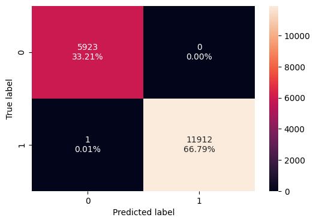

```python
# draw confusion matrix of train data on random forest classifier
confusion_matrix_sklearn(rf_estimator,X_train,y_train)
```

#### Observations

- True positive: 33.21% the model predicted the visa application will get correctly certified.
- False negative: 0% the model predicted the visa application will not get certified but in reality, the visa application should get certified.
- False positive: 0.01% the model predicted the visa application will get certified, but in reallity, the vias application should get denied.
- True negative: 66.79% the model predicted the visa application will get correctly denied.

```python
# check performance of train data on random forest classifier
rf_estimator_model_train_perf = model_performance_classification_sklearn(rf_estimator,X_train,y_train)
rf_estimator_model_train_perf
```

|  | Accuracy | Recall | Precision | F1 |
| --- | --- | --- | --- | --- |
| 0 | 0.999944 | 0.999916 | 1.0 | 0.999958 |

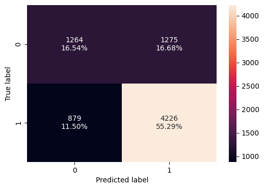

```python
# draw confusion matrix of test data on random forest classifier
confusion_matrix_sklearn(rf_estimator,X_test,y_test)
```

#### Observations

- True positive: 16.54% the model predicted the visa application will get correctly certified.
- False negative: 16.68% the model predicted the visa application will not get certified but in reality, the visa application should get certified.
- False positive: 11.5% the model predicted the visa application will get certified, but in reallity, the vias application should get denied.
- True negative: 55.29% the model predicted the visa application will get correctly denied.

```python
# check performance of test data on random forest classifier
rf_estimator_model_test_perf = model_performance_classification_sklearn(rf_estimator,X_test,y_test)
rf_estimator_model_test_perf
```

|  | Accuracy | Recall | Precision | F1 |
| --- | --- | --- | --- | --- |
| 0 | 0.71821 | 0.827816 | 0.768224 | 0.796907 |

#### Observations

- The train set results indicate that the model achieved high accuracy (0.9999), recall (0.9999), precision (1.0), and F1-score (0.9999). This suggests that the model performed very well on the train set and was able to correctly predict almost all of the samples.
- The test set shows lower accuracy (0.72), recall (0.83), precision (0.77), and F1-score (0.8).
- The lower precision and F1-score suggest that the model may have higher false positive rates on the test set.
- This suggests the model is overfitting.

#### Will tuning the hyperparameters improve the model performance?

```python
# tuned random forest classifier
rf_tuned = RandomForestClassifier(random_state=1, oob_score=True, bootstrap=True)

# grid of parameters
parameters = {
    'max_depth': list(np.arange(5, 15, 5)),
    'max_features': ["sqrt", "log2"],
    'min_samples_split': [5, 7],
    'n_estimators': np.arange(15, 26, 5),
}

# set scorer to f1_score
acc_scorer = metrics.make_scorer(metrics.f1_score)

# run grid search
grid_obj = GridSearchCV(rf_tuned, parameters, cv=5, n_jobs=-1, scoring=acc_scorer)

# fit tuned model to trains set
grid_obj = grid_obj.fit(X_train, y_train)

# set clf to best combination of parameters
rf_tuned = grid_obj.best_estimator_

# fit best algorithm
rf_tuned.fit(X_train, y_train)
```

[output not shown]

[output cut: 25 more lines]

[output not shown]

```
RandomForestClassifier(max_depth=10, max_features='log2', min_samples_split=5,
                       n_estimators=25, oob_score=True, random_state=1)
```

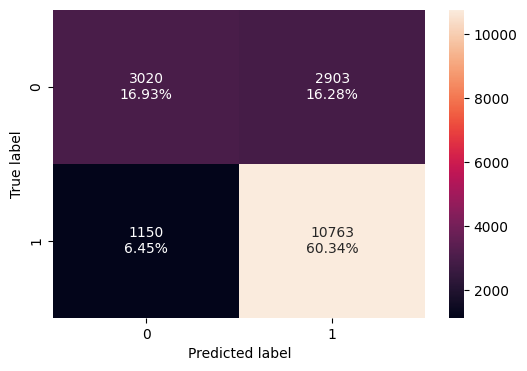

```python
# draw confusion matrix of train data on tuned random forest classifier
confusion_matrix_sklearn(rf_tuned,X_train,y_train)
```

#### Observations

- True positive: 16.93% the model predicted the visa application will get correctly certified.
- False negative: 16.28% the model predicted the visa application will not get certified but in reality, the visa application should get certified.
- False positive: 6.45% the model predicted the visa application will get certified, but in reallity, the vias application should get denied.
- True negative: 60.34% the model predicted the visa application will get correctly denied.

```python
# check performance of train data on tuned random forest classifier
rf_tuned_model_train_perf = model_performance_classification_sklearn(rf_tuned,X_train,y_train)
rf_tuned_model_train_perf
```

|  | Accuracy | Recall | Precision | F1 |
| --- | --- | --- | --- | --- |
| 0 | 0.772763 | 0.903467 | 0.787575 | 0.84155 |

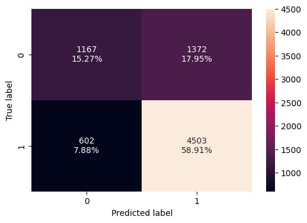

```python
# draw confusion matrix of test data on tuned random forest classifier
confusion_matrix_sklearn(rf_tuned,X_test,y_test)
```

#### Observations

- True positive: 15.27% the model predicted the visa application will get correctly certified.
- False negative: 17.95% the model predicted the visa application will not get certified but in reality, the visa application should get certified.
- False positive: 7.88% the model predicted the visa application will get certified, but in reallity, the vias application should get denied.
- True negative: 58.91% the model predicted the visa application will get correctly denied.

```python
# check performance of test data on tuned random forest classifier
rf_tuned_model_test_perf = model_performance_classification_sklearn(rf_tuned,X_test,y_test)
rf_tuned_model_test_perf
```

|  | Accuracy | Recall | Precision | F1 |
| --- | --- | --- | --- | --- |
| 0 | 0.741758 | 0.882076 | 0.766468 | 0.820219 |

#### Observations

- The training set shows accuracy (0.77), which means that the model correctly classified about 77% of the instances in the training set.
- Recall of 0.90 indicates that the model was able to correctly identify about 90% of the positive instances in the training set.
- Precision score of 0.79 shows that when the model predicted an instance to be positive, it was correct about 79% of the time.
- F1-score of 0.84 balances both measure of precision and recall as the harmonic mean.
- The test set shows accuracy (0.74), lower than the training set accuracy, indicating that the model may be overfitting to the training set.
- Recall (0.88) is similar to the training set, indicating that the model was able to correctly identify about 88% of the positive instances in the test set.
- Precision score (0.77) shows that when the model predicted an instance to be positive, it was correct about 77% of the time.
- F1-score of 0.82 is slightly lower than the training set, indicating that the model may not generalize well to new data.
- There is a possibility the model is overfitting.

#### AdaBoost Classifier

```python
# create AdaBoost classifier
ab_classifier = AdaBoostClassifier(random_state=1)

# fit model to train set
ab_classifier.fit(X_train,y_train)
```

```
AdaBoostClassifier(random_state=1)
```

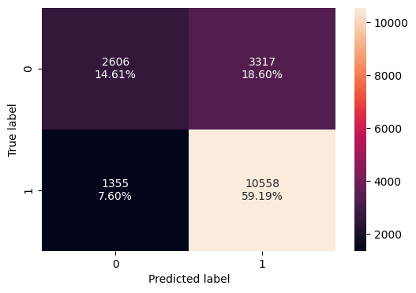

```python
# draw confusion matrix of train data on AdaBoost classifier
confusion_matrix_sklearn(ab_classifier,X_train,y_train)
```

#### Observations

- True positive: 14.61% the model predicted the visa application will get correctly certified.
- False negative: 18.6% the model predicted the visa application will not get certified but in reality, the visa application should get certified.
- False positive: 7.6% the model predicted the visa application will get certified, but in reallity, the vias application should get denied.
- True negative: 59.19% the model predicted the visa application will get correctly denied.

```python
# check performance of train data on AdaBoost classifier
ab_classifier_model_train_perf = model_performance_classification_sklearn(ab_classifier,X_train,y_train)
ab_classifier_model_train_perf
```

|  | Accuracy | Recall | Precision | F1 |
| --- | --- | --- | --- | --- |
| 0 | 0.738058 | 0.886259 | 0.760937 | 0.81883 |

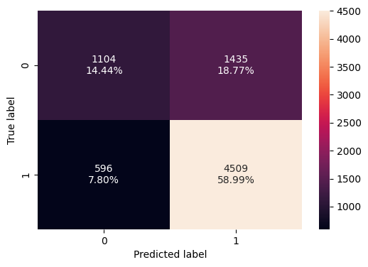

```python
# draw confusion matrix of test data on AdaBoost classifier
confusion_matrix_sklearn(ab_classifier,X_test,y_test)
```

#### Observations

- True positive: 14.44% the model predicted the visa application will get correctly certified.
- False negative: 18.77% the model predicted the visa application will not get certified but in reality, the visa application should get certified.
- False positive: 7.8% the model predicted the visa application will get certified, but in reallity, the vias application should get denied.
- True negative: 58.99% the model predicted the visa application will get correctly denied.

```python
# check performance of test data on AdaBoost classifier
ab_classifier_model_test_perf = model_performance_classification_sklearn(ab_classifier,X_test,y_test)
ab_classifier_model_test_perf
```

|  | Accuracy | Recall | Precision | F1 |
| --- | --- | --- | --- | --- |
| 0 | 0.734301 | 0.883252 | 0.75858 | 0.816182 |

#### Observations

- The results show that the model has similar performance on the training and test sets.
- Overall, these results suggest that the model is not overfitting.

#### Will tuning the hyperparameters improve the model performance?

```python
# tuned AdaBoost classifier
abc_tuned = AdaBoostClassifier(random_state=1)

# grid of parameters
parameters = {
    'base_estimator': [
        DecisionTreeClassifier(max_depth=1, class_weight='balanced', random_state=1),
        DecisionTreeClassifier(max_depth=2, class_weight='balanced', random_state=1),
    ],
    'n_estimators': np.arange(80, 101, 10),
    'learning_rate': np.arange(0.1, 0.4, 0.1),
}

# set scorer to f1_score
acc_scorer = metrics.make_scorer(metrics.f1_score)

# run grid search
grid_obj = GridSearchCV(abc_tuned, parameters, cv=5, scoring=acc_scorer)

# fit tuned model on train set
grid_obj = grid_obj.fit(X_train, y_train)

# set clf to best combination of parameters
abc_tuned = grid_obj.best_estimator_

# fit best algorithm
abc_tuned.fit(X_train, y_train)
```

```
AdaBoostClassifier(base_estimator=DecisionTreeClassifier(class_weight='balanced',
                                                         max_depth=1,
                                                         random_state=1),
                   learning_rate=0.1, n_estimators=100, random_state=1)
```

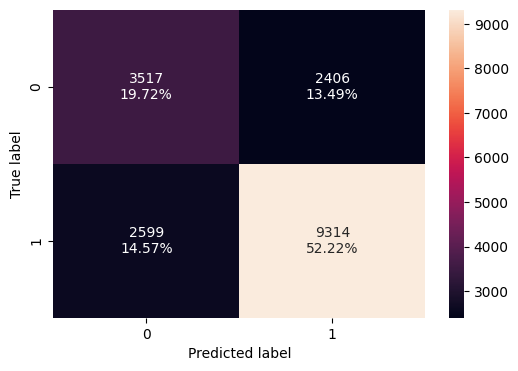

```python
# draw confusion matrix of train data on tuned AdaBoost classifier
confusion_matrix_sklearn(abc_tuned,X_train,y_train)
```

#### Observations

- True positive: 19.72% the model predicted the visa application will get correctly certified.
- False negative: 13.49% the model predicted the visa application will not get certified but in reality, the visa application should get certified.
- False positive: 14.57% the model predicted the visa application will get certified, but in reallity, the vias application should get denied.
- True negative: 52.22% the model predicted the visa application will get correctly denied.

```python
# check performance of trained data on tuned AdaBoost classifier
abc_tuned_model_tuned_train_perf = model_performance_classification_sklearn(abc_tuned,X_train,y_train)
abc_tuned_model_tuned_train_perf
```

|  | Accuracy | Recall | Precision | F1 |
| --- | --- | --- | --- | --- |
| 0 | 0.719388 | 0.781835 | 0.79471 | 0.78822 |

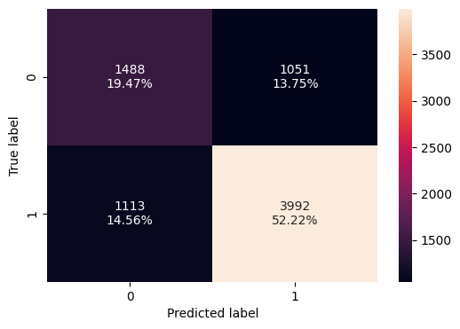

```python
# draw confusion matrix of test data on tuned AdaBoost classifier
confusion_matrix_sklearn(abc_tuned,X_test,y_test)
```

#### Observations

- True positive: 19.47% the model predicted the visa application will get correctly certified.
- False negative: 13.75% the model predicted the visa application will not get certified but in reality, the visa application should get certified.
- False positive: 14.56% the model predicted the visa application will get certified, but in reallity, the vias application should get denied.
- True negative: 52.22% the model predicted the visa application will get correctly denied.

```python
# check performance of test data on tuned AdaBoost classifier
abc_tuned_model_tuned_test_perf = model_performance_classification_sklearn(abc_tuned,X_test,y_test)
abc_tuned_model_tuned_test_perf
```

|  | Accuracy | Recall | Precision | F1 |
| --- | --- | --- | --- | --- |
| 0 | 0.716902 | 0.781978 | 0.791592 | 0.786756 |

#### Observations

- The results show that the tuned AdaBoost classifier performed relatively well on both the train and test sets.
- There may be slight overfitting.
- The accuracy scores are moderate, indicating that the model is predicting the correct class for around 70% of the data points in both sets.
- Recall scores indicate that the model is identifying around 78% of the true positive cases.
- Precision scores indicate that around 79% of the predicted positive cases are actually true positive cases.
- F1-scores, which provide a balance between precision and recall, are around 79%, suggesting that the model is performing reasonably well overall.

#### Gradient Boosting Classifier

```python
# create gradient boosting classifier
gb_classifier = GradientBoostingClassifier(random_state=1)

# fit model on train set
gb_classifier.fit(X_train,y_train)
```

```
GradientBoostingClassifier(random_state=1)
```

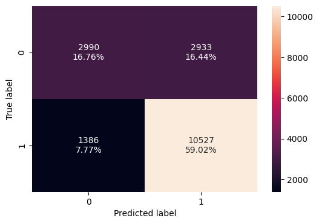

```python
# draw confusion matrix of train data on gradient classifier
confusion_matrix_sklearn(gb_classifier,X_train,y_train)
```

#### Observations

- True positive: 16.76% the model predicted the visa application will get correctly certified.
- False negative: 16.44% the model predicted the visa application will not get certified but in reality, the visa application should get certified.
- False positive: 7.77% the model predicted the visa application will get certified, but in reallity, the vias application should get denied.
- True negative: 59.02% the model predicted the visa application will get correctly denied.

```python
# check performance of train data on gradient classifier
gb_classifier_model_train_perf = model_performance_classification_sklearn(gb_classifier,X_train,y_train)
gb_classifier_model_train_perf
```

|  | Accuracy | Recall | Precision | F1 |
| --- | --- | --- | --- | --- |
| 0 | 0.757849 | 0.883657 | 0.782095 | 0.82978 |

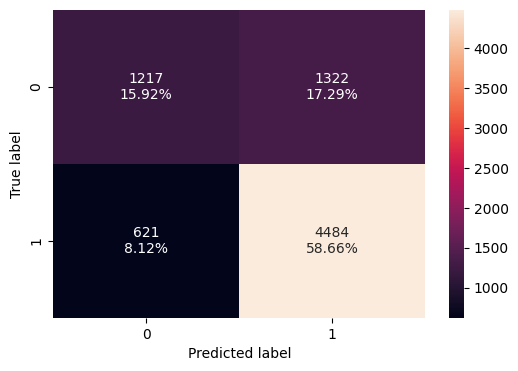

```python
# draw confusion matrix of test data on gradient classifier
confusion_matrix_sklearn(gb_classifier,X_test,y_test)
```

#### Observations

- True positive: 15.92% the model predicted the visa application will get correctly certified.
- False negative: 17.29% the model predicted the visa application will not get certified but in reality, the visa application should get certified.
- False positive: 8.12% the model predicted the visa application will get certified, but in reallity, the vias application should get denied.
- True negative: 58.66% the model predicted the visa application will get correctly denied.

```python
# check performance of test data on gradient classifier
gb_classifier_model_test_perf = model_performance_classification_sklearn(gb_classifier,X_test,y_test)
gb_classifier_model_test_perf
```

|  | Accuracy | Recall | Precision | F1 |
| --- | --- | --- | --- | --- |
| 0 | 0.745814 | 0.878355 | 0.772305 | 0.821923 |

#### Observations

- The model has accuracy 75.78% on the train set and an accuracy of 74.58% on the test set.
- Recall for the train set is 88.37% which means that 88.37% of the positive instances were correctly classified.
- Precision for the train set is 78.21% which means that 78.21% of the instances predicted as positive were actually positive.
- F1-score for the train set is 82.97%.
- For the test set, the recall is 87.84% which means that 87.84% of the positive instances were correctly classified.
- Precision for the test set is 77.23% which means that 77.23% of the instances predicted as positive were actually positive.
- F1-score for the test set is 82.19%.
- The results show that the model is performing reasonably well. The performance on the train and test sets is relatively similar, which suggests that the model is not overfitting to the train data.

#### Will tuning the hyperparameters improve the model performance?

```python
# tuned gradient boosting classifier
gbc_tuned = GradientBoostingClassifier(
    init=AdaBoostClassifier(random_state=1), random_state=1
)

# grid of parameters
parameters = {
    'n_estimators': [200, 250],
    'subsample': [0.9, 1],
    'max_features': [0.8, 0.9],
    'learning_rate': np.arange(0.1, 0.21, 0.1),
}

# set scorer to f1_score
acc_scorer = metrics.make_scorer(metrics.f1_score)

# run grid search
grid_obj = GridSearchCV(gbc_tuned, parameters, scoring=acc_scorer,cv=5)

# fit tuned model to train set
grid_obj = grid_obj.fit(X_train, y_train)

# set clf to best combination of parameters
gbc_tuned = grid_obj.best_estimator_

# fit best algorithm
gbc_tuned.fit(X_train, y_train)
```

```
GradientBoostingClassifier(init=AdaBoostClassifier(random_state=1),
                           max_features=0.9, n_estimators=200, random_state=1,
                           subsample=0.9)
```

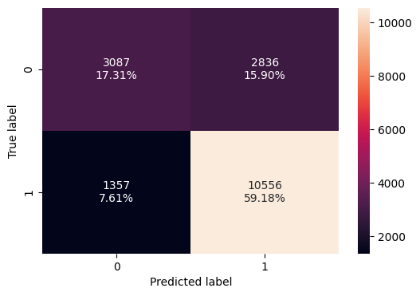

```python
# draw confusion matrix of train data on tuned gradient classifier
confusion_matrix_sklearn(gbc_tuned,X_train,y_train)
```

#### Observations

- True positive: 17.31% the model predicted the visa application will get correctly certified.
- False negative: 15.9% the model predicted the visa application will not get certified but in reality, the visa application should get certified.
- False positive: 7.61% the model predicted the visa application will get certified, but in reallity, the vias application should get denied.
- True negative: 59.18% the model predicted the visa application will get correctly denied.

```python
# check performance of train data on tuned gradient classifier
gbc_tuned_model_train_perf = model_performance_classification_sklearn(gbc_tuned,X_train,y_train)
gbc_tuned_model_train_perf
```

|  | Accuracy | Recall | Precision | F1 |
| --- | --- | --- | --- | --- |
| 0 | 0.764914 | 0.886091 | 0.788232 | 0.834302 |

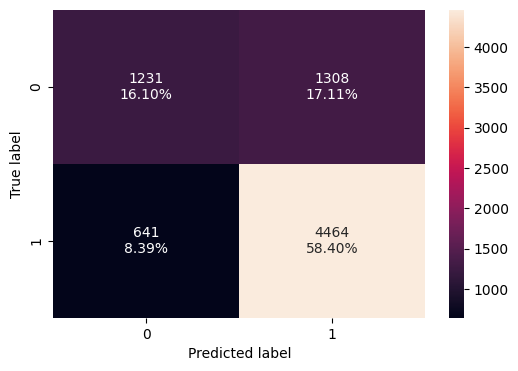

```python
# draw confusion matrix of test data on tuned gradient classifier
confusion_matrix_sklearn(gbc_tuned,X_test,y_test)
```

#### Observations

- True positive: 16.1% the model predicted the visa application will get correctly certified.
- False negative: 17.11% the model predicted the visa application will not get certified but in reality, the visa application should get certified.
- False positive: 8.39% the model predicted the visa application will get certified, but in reallity, the vias application should get denied.
- True negative: 58.4% the model predicted the visa application will get correctly denied.

```python
# check performance of test data on tuned gradient classifier
gbc_tuned_model_test_perf = model_performance_classification_sklearn(gbc_tuned,X_test,y_test)
gbc_tuned_model_test_perf
```

|  | Accuracy | Recall | Precision | F1 |
| --- | --- | --- | --- | --- |
| 0 | 0.745029 | 0.874437 | 0.773389 | 0.820815 |

#### Observations

- Accuracy of the training set is 76.49%, while accuracy on the test set is 74.5%, The lower test set accueacy suggests that the model may be overfitting to the training data.
- Recall of the training set is 88.61%, while recall on the test set is 87.44%. The lower test set recall suggests that the model may be missing some of the positive instances in the test set.
- Precision of the training set is 78.82%, while precision on the test set is 77.34%. The lower test set precision suggests that the model may be identifying some false positives in the test set.
- F1_Score of the training set is 83.43%, while f1_score on the test set is 82.08%. The lower test set f1_score suggests that the model may be slightly overfitting to the training data.
- Overall, the model is performing reasonably well on both the training and test sets. However, there may be some degree of overfitting to the training data.

#### XGBoost Classifier

```python
# create XGBoost classifier
xgb_classifier = XGBClassifier(random_state=1, eval_metric='logloss')

# fit model to train set
xgb_classifier.fit(X_train,y_train)
```

```
XGBClassifier(base_score=None, booster=None, callbacks=None,
              colsample_bylevel=None, colsample_bynode=None,
              colsample_bytree=None, early_stopping_rounds=None,
              enable_categorical=False, eval_metric='logloss',
              feature_types=None, gamma=None, gpu_id=None, grow_policy=None,
              importance_type=None, interaction_constraints=None,
              learning_rate=None, max_bin=None, max_cat_threshold=None,
              max_cat_to_onehot=None, max_delta_step=None, max_depth=None,
              max_leaves=None, min_child_weight=None, missing=nan,
              monotone_constraints=None, n_estimators=100, n_jobs=None,
              num_parallel_tree=None, predictor=None, random_state=1, ...)
```

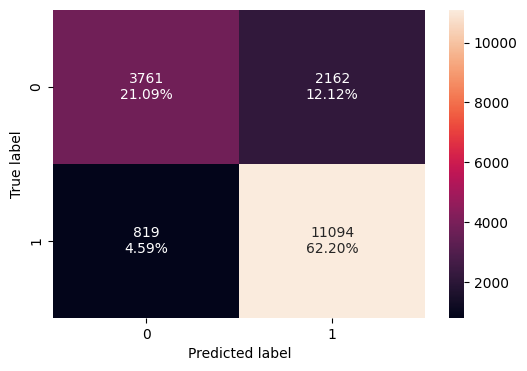

```python
# draw confusion matrix of train data on XGBoost classifier
confusion_matrix_sklearn(xgb_classifier,X_train,y_train)
```

#### Observations

- True positive: 21.09% the model predicted the visa application will get correctly certified.
- False negative: 12.12% the model predicted the visa application will not get certified but in reality, the visa application should get certified.
- False positive: 4.59% the model predicted the visa application will get certified, but in reallity, the vias application should get denied.
- True negative: 62.2% the model predicted the visa application will get correctly denied.

```python
# check performance of train data on XGBoost classifier
xgb_classifier_model_train_perf = model_performance_classification_sklearn(xgb_classifier,X_train,y_train)
xgb_classifier_model_train_perf
```

|  | Accuracy | Recall | Precision | F1 |
| --- | --- | --- | --- | --- |
| 0 | 0.832866 | 0.931252 | 0.836904 | 0.881561 |

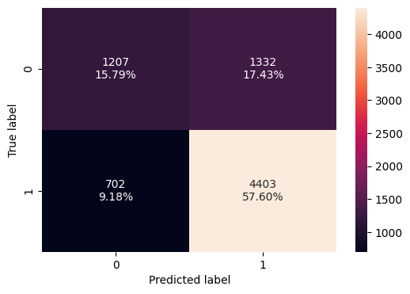

```python
# draw confusion matrix of test data on XGBoost classifier
confusion_matrix_sklearn(xgb_classifier,X_test,y_test)
```

#### Observations

- True positive: 15.79% the model predicted the visa application will get correctly certified.
- False negative: 17.43% the model predicted the visa application will not get certified but in reality, the visa application should get certified.
- False positive: 9.18% the model predicted the visa application will get certified, but in reallity, the vias application should get denied.
- True negative: 57.6% the model predicted the visa application will get correctly denied.

```python
# check performance of test data on XGBoost classifier
xgb_classifier_model_test_perf = model_performance_classification_sklearn(xgb_classifier,X_test,y_test)
xgb_classifier_model_test_perf
```

|  | Accuracy | Recall | Precision | F1 |
| --- | --- | --- | --- | --- |
| 0 | 0.733909 | 0.862488 | 0.767742 | 0.812362 |

#### Observations

- Accuracy of the training set is 83.29%, while accuracy on the test set is 73.39%. The lower test set accuracy suggests that the model may be overfitting to some extent, but the drop in accuracy is not too large.
- Recall of the training set is 93.13%, while recall on the test set is 86.25%. The lower test set recall suggests that the model may be missing some of the positive instances in the test set.
- Pecision of the model on the training set is 83.69%, while precision on the test set is 76.77%. The lower test set precision suggests that the model may be identifying some false positives in the test set.
- F1_score of the training set is 88.16%, while f1_score on the test set is 81.24%. The lower test set f1_Score suggests that the model may be overfitting to the training data.
- Overall, there may be some degree of overfitting to the training data.

#### Will tuning the hyperparameters improve the model performance?

```python
# tuned XGBoost classifier
xgb_tuned = XGBClassifier(random_state=1, eval_metric='logloss')

# grid of parameters
parameters = {
    'n_estimators': np.arange(150, 250, 50),
    'scale_pos_weight': [1, 2],
    'subsample': [0.9, 1],
    'learning_rate': np.arange(0.1, 0.21, 0.1),
    'gamma': [3, 5],
    'colsample_bytree': [0.8, 0.9],
    'colsample_bylevel': [ 0.9, 1],
}

# set scorer to f1_score
acc_scorer = metrics.make_scorer(metrics.f1_score)

# run grid search
grid_obj = GridSearchCV(xgb_tuned, parameters,scoring=acc_scorer,cv=5)

# fit tuned model to train set
grid_obj = grid_obj.fit(X_train, y_train)

# set clf to best combination of parameters
xgb_tuned = grid_obj.best_estimator_

# fit best algorithm
xgb_tuned.fit(X_train, y_train)
```

```
XGBClassifier(base_score=None, booster=None, callbacks=None,
              colsample_bylevel=1, colsample_bynode=None, colsample_bytree=0.9,
              early_stopping_rounds=None, enable_categorical=False,
              eval_metric='logloss', feature_types=None, gamma=5, gpu_id=None,
              grow_policy=None, importance_type=None,
              interaction_constraints=None, learning_rate=0.1, max_bin=None,
              max_cat_threshold=None, max_cat_to_onehot=None,
              max_delta_step=None, max_depth=None, max_leaves=None,
              min_child_weight=None, missing=nan, monotone_constraints=None,
              n_estimators=150, n_jobs=None, num_parallel_tree=None,
              predictor=None, random_state=1, ...)
```

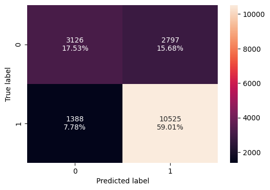

```python
# draw confusion matrix of train data on tuned XGBoost classifier
confusion_matrix_sklearn(xgb_tuned,X_train,y_train)
```

#### Observations

- True positive: 17.53% the model predicted the visa application will get correctly certified.
- False negative: 15.68% the model predicted the visa application will not get certified but in reality, the visa application should get certified.
- False positive: 7.78% the model predicted the visa application will get certified, but in reallity, the vias application should get denied.
- True negative: 59.01% the model predicted the visa application will get correctly denied.

```python
# check performance of train data on tuned XGBoost classifier
xgb_tuned_model_train_perf = model_performance_classification_sklearn(xgb_tuned,X_train,y_train)
xgb_tuned_model_train_perf
```

|  | Accuracy | Recall | Precision | F1 |
| --- | --- | --- | --- | --- |
| 0 | 0.765362 | 0.883489 | 0.790047 | 0.834159 |

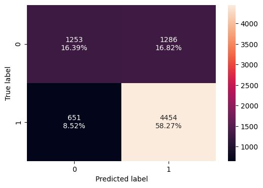

```python
# draw confusion matrix of test data on tuned XGBoost classifier
confusion_matrix_sklearn(xgb_tuned,X_test,y_test)
```

#### Observations

- True positive: 16.39% the model predicted the visa application will get correctly certified.
- False negative: 16.82% the model predicted the visa application will not get certified but in reality, the visa application should get certified.
- False positive: 8.52% the model predicted the visa application will get certified, but in reallity, the vias application should get denied.
- True negative: 58.27% the model predicted the visa application will get correctly denied.

```python
# check performance of test data on tuned XGBoost classifier
xgb_tuned_model_test_perf = model_performance_classification_sklearn(xgb_tuned,X_test,y_test)
xgb_tuned_model_test_perf
```

|  | Accuracy | Recall | Precision | F1 |
| --- | --- | --- | --- | --- |
| 0 | 0.746599 | 0.872478 | 0.775958 | 0.821392 |

#### Stacking Classifier

```python
# select estimators for stacking classifier
estimators = [
    ('AdaBoost', ab_classifier),
    ('Gradient Boosting', gbc_tuned),
    ('Random Forest', rf_tuned),
]

# define final estimator used for predictions
final_estimator = xgb_tuned

# create stacking classifier with base and final estimators
stacking_classifier = StackingClassifier(
    estimators=estimators,
    final_estimator=final_estimator
)

# fit model to train set
stacking_classifier.fit(X_train, y_train)
```

```
StackingClassifier(estimators=[('AdaBoost', AdaBoostClassifier(random_state=1)),
                               ('Gradient Boosting',
                                GradientBoostingClassifier(init=AdaBoostClassifier(random_state=1),
                                                           max_features=0.9,
                                                           n_estimators=200,
                                                           random_state=1,
                                                           subsample=0.9)),
                               ('Random Forest',
                                RandomForestClassifier(max_depth=10,
                                                       max_features='log2',
                                                       min_samples_split=5,
                                                       n_estimators=25,
                                                       oob_score=T...
                                                 gpu_id=None, grow_policy=None,
                                                 importance_type=None,
                                                 interaction_constraints=None,
                                                 learning_rate=0.1,
                                                 max_bin=None,
                                                 max_cat_threshold=None,
                                                 max_cat_to_onehot=None,
                                                 max_delta_step=None,
                                                 max_depth=None,
                                                 max_leaves=None,
                                                 min_child_weight=None,
                                                 missing=nan,
                                                 monotone_constraints=None,
                                                 n_estimators=150, n_jobs=None,
                                                 num_parallel_tree=None,
                                                 predictor=None, random_state=1, ...))
```

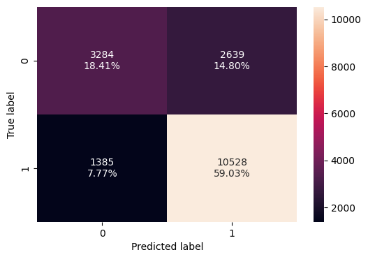

```python
# draw confusion matrix of train data on stacking classifier
confusion_matrix_sklearn(stacking_classifier,X_train,y_train)
```

#### Observations

- True positive: 18.41% the model predicted the visa application will get correctly certified.
- False negative: 14.8% the model predicted the visa application will not get certified but in reality, the visa application should get certified.
- False positive: 7.77% the model predicted the visa application will get certified, but in reallity, the vias application should get denied.
- True negative: 59.03% the model predicted the visa application will get correctly denied.

```python
# check performance of train data on stacking classifier
stacking_classifier_model_train_perf = model_performance_classification_sklearn(stacking_classifier,X_train,y_train)
stacking_classifier_model_train_perf
```

|  | Accuracy | Recall | Precision | F1 |
| --- | --- | --- | --- | --- |
| 0 | 0.774389 | 0.88374 | 0.799575 | 0.839553 |

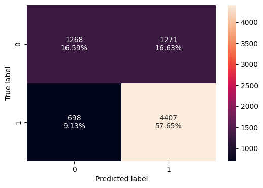

```python
# draw confusion matrix of test data on stacking classifier
confusion_matrix_sklearn(stacking_classifier,X_test,y_test)
```

#### Observations

- True positive: 16.59% the model predicted the visa application will get correctly certified.
- False negative: 16.63% the model predicted the visa application will not get certified but in reality, the visa application should get certified.
- False positive: 9.13% the model predicted the visa application will get certified, but in reallity, the vias application should get denied.
- True negative: 57.65% the model predicted the visa application will get correctly denied.

```python
# check performance of test data on stacking classifier
stacking_classifier_model_test_perf = model_performance_classification_sklearn(stacking_classifier,X_test,y_test)
stacking_classifier_model_test_perf
```

|  | Accuracy | Recall | Precision | F1 |
| --- | --- | --- | --- | --- |
| 0 | 0.742412 | 0.863271 | 0.776154 | 0.817398 |

#### Observations

- Overall, the results suggest that both models have performed relatively well. However, the accuracy and f1_score for the testing set are lower than scores for the training set. This indicates there may be some overfitting. The recall scores for both sets are high, indicating that the model is able to identify most of the positive instances.

## Model Performance Comparison and Conclusions

```python
# training performance comparison

models_train_comp_df = pd.concat(
    [
    decision_tree_perf_train.T,
     dtree_estimator_model_train_perf.T,
     bagging_classifier_model_train_perf.T,
     bagging_classifier_model_tuned_train_perf.T,
     rf_estimator_model_train_perf.T,
     rf_tuned_model_train_perf.T,
     ab_classifier_model_train_perf.T,
     abc_tuned_model_tuned_train_perf.T,
     gb_classifier_model_train_perf.T,
     gbc_tuned_model_train_perf.T,
     xgb_classifier_model_train_perf.T,
     xgb_tuned_model_train_perf.T,
     stacking_classifier_model_train_perf.T,
     ],
     axis=1,
    )
models_train_comp_df.columns = [
    "Decision Tree",
    "Tuned Decision Tree",
    "Bagging Classifier",
    "Tuned Bagging Classifier",
    "Random Forest",
    "Tuned Random Forest",
    "Adaboost Classifier",
    "Tuned Adaboost Classifier",
    "Gradient Boost Classifier",
    "Tuned Gradient Boost Classifier",
    "XGBoost Classifier",
    "XGBoost Classifier Tuned",
    "Stacking Classifier",
]
print("Training performance comparison:")
models_train_comp_df
```

```
Training performance comparison:
```

|  | Decision Tree | Tuned Decision Tree | Bagging Classifier | Tuned Bagging Classifier | Random Forest | Tuned Random Forest | Adaboost Classifier | Tuned Adaboost Classifier | Gradient Boost Classifier | Tuned Gradient Boost Classifier | XGBoost Classifier | XGBoost Classifier Tuned | Stacking Classifier |
| --- | --- | --- | --- | --- | --- | --- | --- | --- | --- | --- | --- | --- | --- |
| Accuracy | 1.0 | 0.712548 | 0.983797 | 0.995234 | 0.999944 | 0.772763 | 0.738058 | 0.719388 | 0.757849 | 0.764914 | 0.832866 | 0.765362 | 0.774389 |
| Recall | 1.0 | 0.931923 | 0.984639 | 0.999496 | 0.999916 | 0.903467 | 0.886259 | 0.781835 | 0.883657 | 0.886091 | 0.931252 | 0.883489 | 0.883740 |
| Precision | 1.0 | 0.720067 | 0.991044 | 0.993409 | 1.000000 | 0.787575 | 0.760937 | 0.794710 | 0.782095 | 0.788232 | 0.836904 | 0.790047 | 0.799575 |
| F1 | 1.0 | 0.812411 | 0.987831 | 0.996443 | 0.999958 | 0.841550 | 0.818830 | 0.788220 | 0.829780 | 0.834302 | 0.881561 | 0.834159 | 0.839553 |

#### Observations

```python
# testing performance comparison

models_test_comp_df = pd.concat(
    [
        decision_tree_perf_test.T,
     dtree_estimator_model_test_perf.T,
     bagging_classifier_model_test_perf.T,
     bagging_classifier_model_tuned_test_perf.T,
     rf_estimator_model_test_perf.T,
     rf_tuned_model_test_perf.T,
     ab_classifier_model_test_perf.T,
     abc_tuned_model_tuned_test_perf.T,
     gb_classifier_model_test_perf.T,
     gbc_tuned_model_test_perf.T,
     xgb_classifier_model_test_perf.T,
     xgb_tuned_model_test_perf.T,
     stacking_classifier_model_test_perf.T,
     ],
     axis=1,
    )
models_test_comp_df.columns = [
    "Decision Tree",
    "Tuned Decision Tree",
    "Bagging Classifier",
    "Tuned Bagging Classifier",
    "Random Forest",
    "Tuned Random Forest",
    "Adaboost Classifier",
    "Tuned Adaboost Classifier",
    "Gradient Boost Classifier",
    "Tuned Gradient Boost Classifier",
    "XGBoost Classifier",
    "XGBoost Classifier Tuned",
    "Stacking Classifier",
]
print("Testing performance comparison:")
models_test_comp_df
```

```
Testing performance comparison:
```

|  | Decision Tree | Tuned Decision Tree | Bagging Classifier | Tuned Bagging Classifier | Random Forest | Tuned Random Forest | Adaboost Classifier | Tuned Adaboost Classifier | Gradient Boost Classifier | Tuned Gradient Boost Classifier | XGBoost Classifier | XGBoost Classifier Tuned | Stacking Classifier |
| --- | --- | --- | --- | --- | --- | --- | --- | --- | --- | --- | --- | --- | --- |
| Accuracy | 0.660387 | 0.706567 | 0.704212 | 0.731293 | 0.718210 | 0.741758 | 0.734301 | 0.716902 | 0.745814 | 0.745029 | 0.733909 | 0.746599 | 0.742412 |
| Recall | 0.739275 | 0.930852 | 0.777081 | 0.874241 | 0.827816 | 0.882076 | 0.883252 | 0.781978 | 0.878355 | 0.874437 | 0.862488 | 0.872478 | 0.863271 |
| Precision | 0.748958 | 0.715447 | 0.779371 | 0.759660 | 0.768224 | 0.766468 | 0.758580 | 0.791592 | 0.772305 | 0.773389 | 0.767742 | 0.775958 | 0.776154 |
| F1 | 0.744085 | 0.809058 | 0.778225 | 0.812933 | 0.796907 | 0.820219 | 0.816182 | 0.786756 | 0.821923 | 0.820815 | 0.812362 | 0.821392 | 0.817398 |

#### Observations

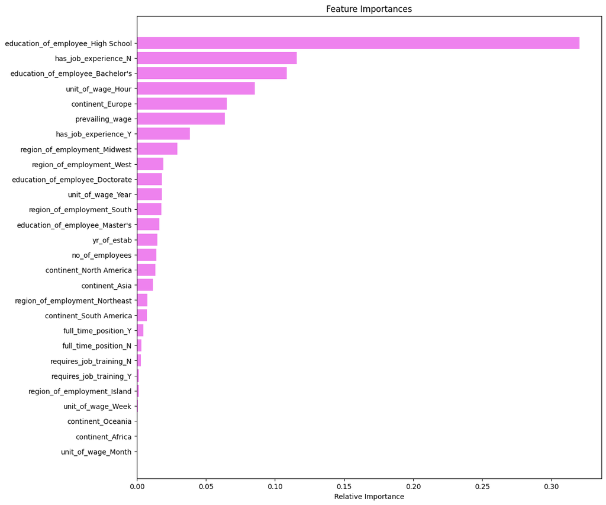

```python
# Get the column names of the training data
feature_names = X_train.columns

# Get the feature importances generated by the Gradient Boost Classifier model
importances = gb_classifier.feature_importances_

# Get the indices of the importances array in ascending order
indices = np.argsort(importances)

# Create a new figure with a size of 12 x 12 inches
plt.figure(figsize=(12, 12))

# Set the title of the plot
plt.title("Feature Importances")

# Plot horizontal bar chart with the feature importances
# The range of the x-axis is the length of the indices array
# The y-axis is labeled with the feature names corresponding to the indices
plt.barh(range(len(indices)), importances[indices], color="violet", align="center")

# Label the y-axis ticks with the feature names
plt.yticks(range(len(indices)), [feature_names[i] for i in indices])

# Label the x-axis with the "Relative Importance"
plt.xlabel("Relative Importance")

# Display the plot
plt.show()
```

#### Observations

- Having a high school education is the most important feature for determinging visa certification or denial.

## Business Insights and Recommendations

#### Insights

There are three pre-screening components that have the most affect on the Office of Foreign Labor Certification's (OFLC) decision for certification or denial of a visa application:

1. Education level: An applicant possessing only a high school diploma has more than a 65% chance of visa denial. Overall, there are less denied applications proportionately among higher education categories: Bachelor's, Master's, and Doctorate.
2. Prior experience: Exploratory analysis showed 56% of applicants with no prior job experiences recieve certification, while 74.5% of applicants with previous job experience recieve certification. The model shows no previous experience as the second most important prediction feature, making the preference towards job experience and positive certification status a vital pre-screening component.
3. Prevailing wage: Exploratory analysis showed outlies in both distributions for certified and denied applications, signifying obvious exceptions. However, overall, the median prevailing wage is slightly higher for certified applications which matches up with the need for education level pre-screening considerations. Higher education typically equates to a higher salary, accounting for the increase in median wage among certified applications. EDA showed a 65% chance of visa application denial among applicants with houry prevailing wage units. This aligns with our model's feature importances showing hourly wage is an important pre-screening consiuderation for the OFLC.

#### Recommendations

Like most U.S. government offics, the OFLC has limited resources and high demands to meet. To prioritize these limited resources, the OFLC can:

1. Sort applications by education level. Applicants with higher levels of education are given higher precedence and reviewed first.
2. Sort applications by previous experience. Review applicants with prioro job experience before those with no prior experience.
3. Sort applications by unit of wage. Applications using annual measurements for prevailing wage receive precedence over those with hourly units. Concurrently, the higher the prevailing wage the more precedence it receives.

The F1-score metric was used to balance both false positive and false negative outcomes. Both precision and recall were equally important to our dataset and model because:

- If a visa is certified when it should have been denied, a wrong employee will receive a job while a valuable employee or U.S. citizen will miss out on the opportunity.
- If a visa is denied when it should have been certified, the U.S. will lose a suitable employee resource contributing to the economy.

The Gradient Boosting Classifier showed the highest F1-value amongst the testing set classifiers, and a similar performance among the training set, making it an ideal model for our use case.

Overall, less-skilled applicants looking for entry-level positions using an hourly wage are least likely to receive certification. This is not surprising considering immigration is an expensive process for both applicant and the OFLC. Giving precedence to higher wage earners and more skilled workers, fills positions that lead to a more fulfilled economy and fill the wage-to expense gap required to bring an immigrant to the U.S. for employment.